# Example 2

Brian Craft

April 8, 2017

```r
library(knitr)
setwd("~/Documents/Craft-Repo/social_networks/example_2")
read_chunk("example02.R")
knitr::opts_chunk$set(echo = TRUE)
```

## Working with different types of data

### Step 1: Load the necessary libraries and data

```r
library("ggplot2")
# Must load other packages first
library("sand")
library("intergraph")
```

Loading the Southern Women network (Davis data). GraphML format.

```r
# Load data
setwd("~/Documents/Craft-Repo/social_networks/example_2")
davis = read.graph("davis.graphml", format = "graphml")
```

### Step 2: Examine the bipartite network

Verify that it is bipartite.

```r
# Examine data
summary(davis)
```

```
## IGRAPH U-WB 32 89 --
## + attr: id (v/c), x (v/n), y (v/n), type (v/l), label (v/c),
## | weight (e/n)
```

Plot using bipartite layout (better if rotated)

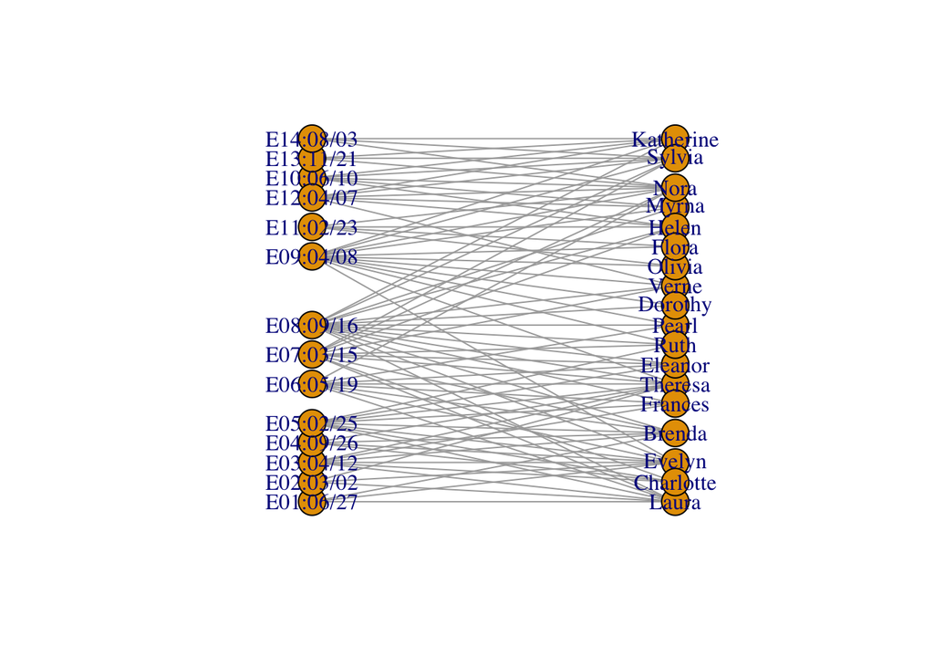

```r
# Plot using bipartite layout
lo = layout.bipartite(davis)
lo2 = cbind(lo[,2],lo[,1])
plot(davis, layout = lo2)
```

Look at labels and types

```r
# Look at labels and types
V(davis)$label[1:5]
```

```
## [1] "Evelyn"    "Laura"     "Theresa"   "Brenda"    "Charlotte"
```

```r
V(davis)$type[1:5]
```

```
## [1] FALSE FALSE FALSE FALSE FALSE
```

So, FALSE is people

### Step 3: Create projection

Create person-person projection

```r
# Create person-person projection
davis.p2p = bipartite.projection(davis, which = "false")
```

Plot the projected graph

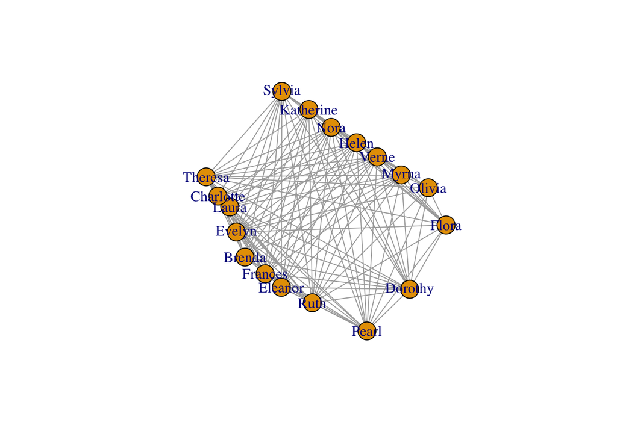

```r
# Plot the projected graph
plot(davis.p2p)
```

Plot the distribution of edge weights

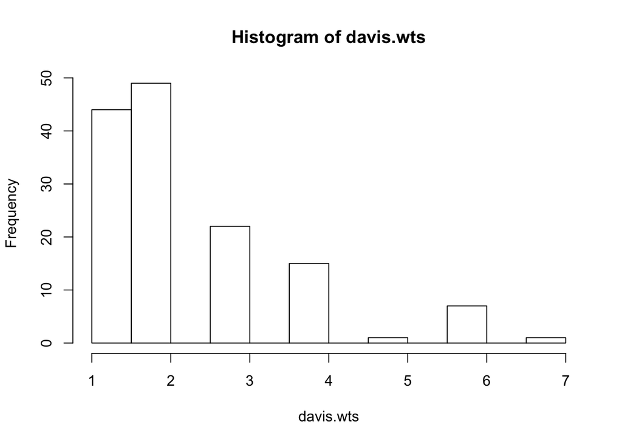

```r
# Plot the distribution of edge weights
davis.wts = E(davis.p2p)$weight
hist(davis.wts)
```

### Step 4: Filtered version of the network

Create a new network removing the edges of weight 1 and 2.

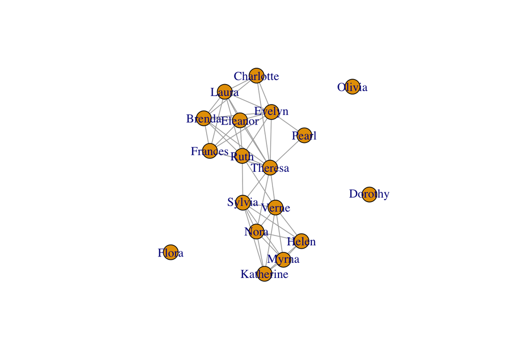

```r
# Create a new network removing the edges of weight 1 and 2.
davis.filt = delete.edges(davis.p2p,
                          E(davis.p2p)[E(davis.p2p)$weight <= 2])
plot(davis.filt, layout = layout.kamada.kawai(davis.filt))
```

Plot the weighted degree distribution of the new network

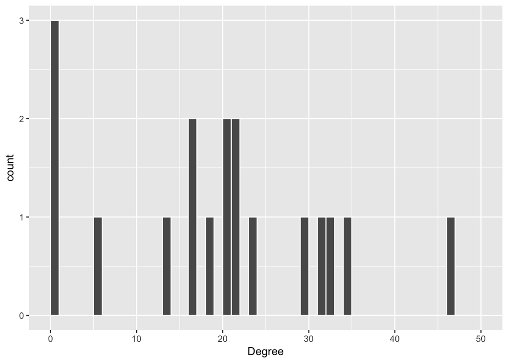

```r
# Plot the weighted degree distribution of the new network
davis.deg = graph.strength(davis.filt)
p = ggplot(data.frame(Degree = davis.deg), aes(x = Degree))
p = p + geom_histogram(breaks = seq(0,50), col = "white")
print(p)
```

### Step 5: Ego networks

Extract the ego networks for Laura and Sylvia

```r
# Extract the ego networks for Laura and Sylvia
which(V(davis.filt)$label == "Laura")
```

```
## [1] 2
```

```r
which(V(davis.filt)$label == "Sylvia")
```

```
## [1] 13
```

```r
egos = make_ego_graph(davis.filt, 1, c(2,13))
laura = egos[[1]]
sylvia = egos[[2]]
```

Plot side-by-side use layout_as_star

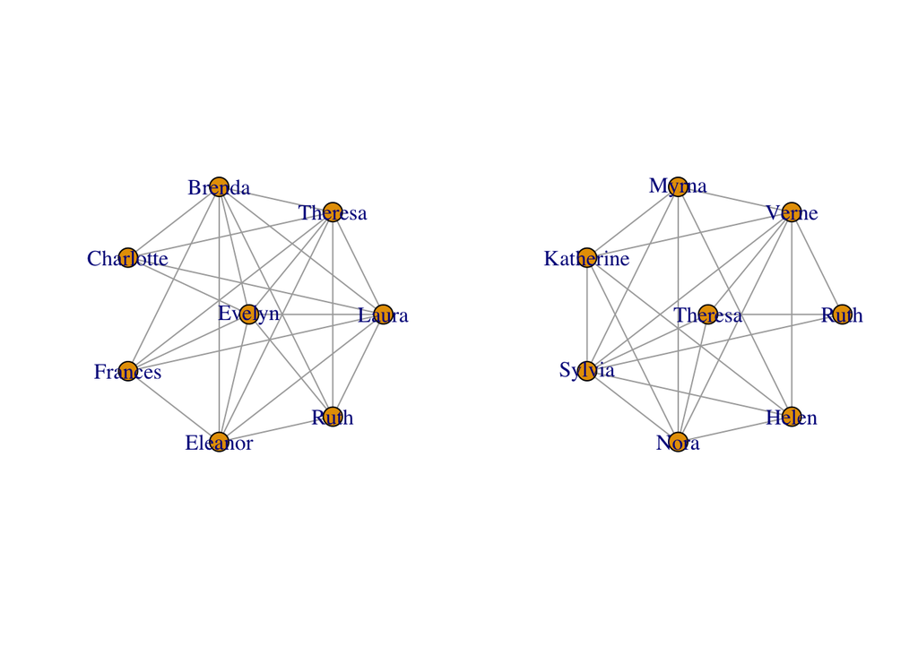

```r
# Plot side-by-side (use par(mfrow...) to do this).
lo_laura = layout_as_star(laura)
lo_sylvia = layout_as_star(sylvia)
par(mfrow = c(1,2))
plot(laura, layout = lo_laura)
plot(sylvia, layout = lo_sylvia)
```

```r
par(mfrow = c(1,1))
```

```r
# Create comparative data frame
```

[output not shown]

```r
# Plot histogram
```

[output not shown]

### Step 6: New example: loading edge and attribute data

Load CSV files for edges and attributes. stringAsFactors is false because we can’t use factors as node attributes.

```r
# Edge and attribute data
edge.df = read.csv("edgelist-sample.csv", stringsAsFactors = FALSE)
node.df = read.csv("nodeattr-sample.csv", stringsAsFactors = FALSE)
edge.df
```

```
##      Node1   Node2 weight
## 1     Anne     Bob      1
## 2     Anne    Carl      4
## 3     Anne    Dave      2
## 4     Anne Earlene      7
## 5      Bob    Carl      4
## 6      Bob Earlene      7
## 7      Bob    Fred      3
## 8      Bob     Guy      5
## 9      Bob     Han     10
## 10    Carl     Guy      9
## 11    Carl     Han      4
## 12    Carl   Irene      5
## 13    Dave    Fred      2
## 14    Dave     Bob      1
## 15 Earlene     Guy      9
## 16 Earlene   Irene      5
## 17    Fred     Guy      4
## 18     Guy    Dave      4
## 19     Han     Guy      9
## 20   Irene     Guy      1
```

```r
node.df
```

```
##      Node Age Sex
## 1    Anne  64   F
## 2     Bob  53   M
## 3    Carl  53   M
## 4    Dave  43   M
## 5 Earlene  54   F
## 6    Fred  50   M
## 7     Guy  43   M
## 8     Han  47   F
## 9   Irene  35   F
```

Convert to a graph from the two data frames. Note that the names of the vertices in the edge data frame have to match the first column of the vertices data frame.

```r
# Convert to graph
graph = graph.data.frame(edge.df, vertices = node.df, directed = FALSE)
```

Plot

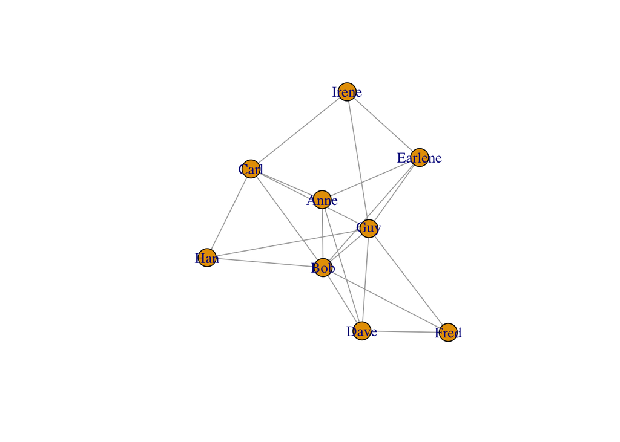

```r
# Plot
plot(graph)
```